# Un Modello Statistico per Prevedere il Peso dei Neonati

Author

Alessandro Capannelli

Per questo studio medico si analizzano i dati raccolti da 3 ospedali, riguardanti 2500 neonati.

In particolare si sono rilevate le seguenti variabili:

- età della madre
- numero di gravidanze sostenute
- Madre fumatrice (0=NO, SI=1)
- N° di settimane di gestazione
- peso in grammi del neonato
- Lunghezza in mm del neonato
- Diametro in mm del cranio del neonato
- Tipo di parto: Naturale o Cesareo
- Ospedale: 1, 2, 3
- Sesso del neonato: M o F

Si vuole scoprire se è possibile prevedere il peso del neonato alla nascita date tutte le altre variabili.

In particolare, si vuole studiare una relazione con le variabili della madre, per capire se queste hanno o meno un effetto significativo, come ad esempio l’effetto potenzialmente dannoso del fumo (nascite premature?). Si usano anche lunghezza e diametro del cranio del neonato perché si possono stimare già dalle ecografie, ma in generale potrebbero anche fungere da variabili di controllo).

Puoi seguire i punti che ti scrivo io come traccia e svolgili uno alla volta, commentando ovviamente i risultati.

## Svolgimento

#### 1. Importa il dataset “neonati.csv” e controlla che sia stato letto correttamente dal software

```r
neonati <- read.csv(here("Dataset", "neonati.csv"), stringsAsFactors = T)
neonati$Fumatrici <- factor(neonati$Fumatrici)
attach(neonati)
```

Si imposta il valore *stringsAsFactors = T* in quanto alcune funzioni che andremo a utilizzare, come `lm()`, necessitano che le variabili testuali siano impostate come fattori. Per lo stesso motivo impostiamo a fattore la variabile *Fumatric*i.

Il dataset è stato letto correttamente.

#### 2. Descrivi il dataset, la sua composizione, il tipo di variabili e l’obbiettivo dello studio

Il dataset possiede un totale di 10 colonne, in particolare:

- **Anni.madre**: variabile quantitativa continua su scala di rapporti
- **N.gravidanze**: variabile quantitativa discreta su scala di rapporti
- **Fumatrici**: variabile categoriale dicotomica (dove 0/1 indicano rispettivamente assenza/presenza della caratteristica “fumatrice”)
- **Gestazione**: variabile quantitativa continua su scala di rapporti
- **Peso**: variabile quantitativa continua su scala di rapporti
- **Lunghezza**: variabile quantitativa continua su scala di rapporti
- **Cranio**: variabile quantitativa continua su scala di rapporti
- **Tipo.parto**: variabile categoriale dicotomica (dove “Ces” indica un parto cesareo, mentre “Nat” un parto naturale)
- **Ospedale**: variabile categoriale politomica (a 3 classi)
- **Sesso**: variabile categoriale dicotomica (dove M indica un neonato di sesso maschile, F di sesso femminile)

L’obiettivo dello studio è quello di fare un’analisi di tipo predittivo sul peso dei neonati. In altre parole, vogliamo studiare se, in che modo e con quale intensità le altre variabili influenzino il peso del neonato, così da essere in grado di stimare quale sarà il peso approssimativo dei futuri neonati al variare di queste variabili (all’interno di un dato intervallo di valori).

#### 3. Indaga le variabili effettuando una breve analisi descrittiva, utilizzando indici e strumenti grafici che conosci

Partiamo analizzando le variabili qualitative - *Fumatrici*, *Tipo.parto*, *Ospedale*, *Sesso* - in particolare costruendo delle tabelle di frequenza, per avere un’idea della distribuzione di frequenza tra le varie modalità:

```r
summarytools::freq(Ospedale,report.nas = FALSE)
```

```
Frequencies
Ospedale
Type: Factor

              Freq        %   % Cum.
----------- ------ -------- --------
       osp1    816    32.64    32.64
       osp2    849    33.96    66.60
       osp3    835    33.40   100.00
      Total   2500   100.00   100.00
```

```r
summarytools::freq(Sesso, report.nas = FALSE)
```

```
Frequencies
Sesso
Type: Factor

              Freq        %   % Cum.
----------- ------ -------- --------
          F   1256    50.24    50.24
          M   1244    49.76   100.00
      Total   2500   100.00   100.00
```

```r
summarytools::freq(Tipo.parto, report.nas = FALSE)
```

```
Frequencies
Tipo.parto
Type: Factor

              Freq        %   % Cum.
----------- ------ -------- --------
        Ces    728    29.12    29.12
        Nat   1772    70.88   100.00
      Total   2500   100.00   100.00
```

```r
summarytools::freq(Fumatrici, report.nas = FALSE)
```

```
Frequencies
Fumatrici
Type: Factor

              Freq        %   % Cum.
----------- ------ -------- --------
          0   2396    95.84    95.84
          1    104     4.16   100.00
      Total   2500   100.00   100.00
```

Da queste tabelle notiamo che il numero di nascite nei tre ospedali hanno valori molto simili tra loro (quindi l’indice di Gini sarà molto vicino ad 1). Allo stesso modo, anche il sesso dei neonati è quasi identico (le femmine rappresentano infatti il 50.24% del campione).

Ci sono differenze significative, come potevamo attenderci, nella frequenze delle modalità delle variabili *Tipo.parto* e *Fumatrici*: i parti cesarei rappresentano poco meno del 30% dei parti totali, mentre solo il 4% delle neo-mamme ha dichiarato di essere fumatrice.

Procediamo poi con la creazione di due tabelle per vedere le frequenze congiunte delle seguenti due coppie di variabili:

- *Ospedale* e *Tipo.parto*: per capire se c’è una differenza evidente nel numero di parti cesarei avvenuti nei tre ospedali

```r
summarytools::ctable(Ospedale, Tipo.parto)
```

```
Cross-Tabulation, Row Proportions
Ospedale * Tipo.parto

---------- ------------ ------------- -------------- ---------------
             Tipo.parto           Ces            Nat           Total
  Ospedale
      osp1                242 (29.7%)    574 (70.3%)    816 (100.0%)
      osp2                254 (29.9%)    595 (70.1%)    849 (100.0%)
      osp3                232 (27.8%)    603 (72.2%)    835 (100.0%)
     Total                728 (29.1%)   1772 (70.9%)   2500 (100.0%)
---------- ------------ ------------- -------------- ---------------
```

- *Fumatrici* e *Tipo.parto*: per capire se è più probabile che chi fuma abbia avuto un parto cesareo (magari legato a un parto prematuro causato proprio dai danni del fumo)

```r
summarytools::ctable(Fumatrici, Tipo.parto)
```

```
Cross-Tabulation, Row Proportions
Fumatrici * Tipo.parto

----------- ------------ ------------- -------------- ---------------
              Tipo.parto           Ces            Nat           Total
  Fumatrici
          0                702 (29.3%)   1694 (70.7%)   2396 (100.0%)
          1                 26 (25.0%)     78 (75.0%)    104 (100.0%)
      Total                728 (29.1%)   1772 (70.9%)   2500 (100.0%)
----------- ------------ ------------- -------------- ---------------
```

In entrambi i casi, limitandoci al momento a unìanalisi “visiva”, non sembrano esserci differenze significative (anzi, il numero di parti naturali sembra essere addirittura più alto per chi fuma, ma il campione relativo alle fumatrici è relativamente piccolo).

Proseguiamo l’analisi descrittiva andando a descrivere le variabili quantitative. Anzitutto procediamo con la funzione `descr()`, che calcola tutti gli indici di posizione, variabilità e forma che ci interessano:

```r
summarytools::descr(neonati[, -c(3,8,9,10)])
```

```
Descriptive Statistics
neonati
N: 2500

                    Anni.madre    Cranio   Gestazione   Lunghezza   N.gravidanze      Peso
----------------- ------------ --------- ------------ ----------- -------------- ---------
             Mean        28.16    340.03        38.98      494.69           0.98   3284.08
          Std.Dev         5.27     16.43         1.87       26.32           1.28    525.04
              Min         0.00    235.00        25.00      310.00           0.00    830.00
               Q1        25.00    330.00        38.00      480.00           0.00   2990.00
           Median        28.00    340.00        39.00      500.00           1.00   3300.00
               Q3        32.00    350.00        40.00      510.00           1.00   3620.00
              Max        46.00    390.00        43.00      565.00          12.00   4930.00
              MAD         4.45     14.83         1.48       22.24           1.48    459.61
              IQR         7.00     20.00         2.00       30.00           1.00    630.00
               CV         0.19      0.05         0.05        0.05           1.31      0.16
         Skewness         0.04     -0.78        -2.06       -1.51           2.51     -0.65
      SE.Skewness         0.05      0.05         0.05        0.05           0.05      0.05
         Kurtosis         0.38      2.94         8.25        6.48          10.98      2.03
          N.Valid      2500.00   2500.00      2500.00     2500.00        2500.00   2500.00
        Pct.Valid       100.00    100.00       100.00      100.00         100.00    100.00
```

Ovviamente, per dare un contesto maggiore a questi dati sarebbe utiule confrontarli con quello di altri paesi “simili” nello stesso periodo, in modo da poter trarre conclusioni più specifiche relative a temi di enorme importanza quali il tasso di natalità di un paese e l’età media dei genitori (studi hanno dimostrato che determinate malattie genetiche dei figli sono più probabili all’aumentare dell’età dei genitori).

In termini di variabilità, invece, andiamo a confrontare il coefficiente di variazione (CV) delle variabili, essendo quest’ultimo un indice relativo che non possiede un’unità di misura propria. La variabile con più alta variabilità risulta essere *N.gravidanze*, con un CV pari a 1.31.

Infine, per quanrto concerne gli indici di forma, notiamo che:

- la curtosi è positiva per tutte le variabili in esame, quindi la distribuzione è leptocurtica, ovvero più alta rispetto alla Normale
- Quasi tutte le variabili hanno una distribuzione asimmetrica (valori negativi indicano una coda più lunga a sinistra e viceversa). In particolare, va sottolineato che anche la variabile *Peso* possiede un certo livello di asimmetria. Ciò è importante in quanto tale asimmetria si rifletterà, probabilmente, anche sui residui. Di conseguenza potrebbe non essere soddisfatto il vincolo di normalità dei residui, come richiesto invece dal modello di regressione lineare. Procediamo quindi con un test Shapiro-Wilk:

  ```r
  shapiro.test(Peso)
  ```

  ```
      Shapiro-Wilk normality test

  data:  Peso
  W = 0.97066, p-value < 2.2e-16
  ```

  Dal quale confermiamo, che è da rifiutare l’ipotesi nulla di normalità di distribuzione della variabile.

  Anche a livello grafico il diagramma a barre sembra evidenziare una certa asimmetria:

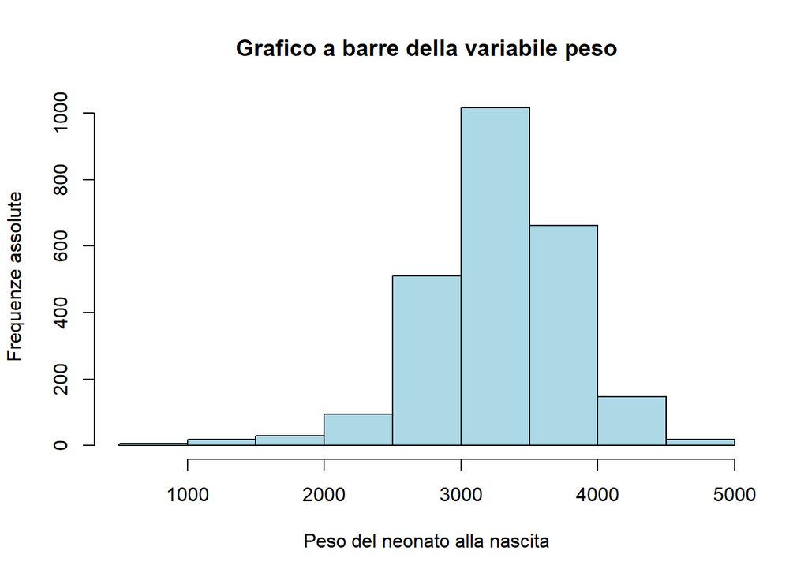

  ```r
  hist(Peso, col = "lightblue", main = "Grafico a barre della variabile peso", xlab = "Peso del neonato alla nascita", ylab = "Frequenze assolute", freq = T)
  ```

#### 4. Saggia l’ipotesi che la media del peso e della lunghezza di questo campione di neonati siano significativamente uguali a quelle della popolazione

Anzitutto identifichiamo il tipo di confronto tra medie che vogliamo verificare. Nel nostro caso, infatti, si tratta di un confronto tra la media di un campione e quella della popolazione, in cui la varianza della popolazione non è nota. Dobbiamo quindi utilizzare un test t-student con n-1 gradi di libertà.

Inoltre si tratta di un test bidirezionale:

##### $H~0~: \bar{x} - µ = 0$

##### $H~1~: \bar{x} - µ \neq 0$

A livello di formule, quindi, la statistica test da calcolare è la seguente:

$$t-test\ =\ \frac{\bar{x}-\mu}{SE}\ con\ n-1\ gdl,\ \ SE\ =\ \frac{s}{\sqrt{n}}$$

Nel nostro caso, poi, manca anche l’informazione relativa al peso medio e alla lunghezza media della popolazione, che ricaviamo effettuando una ricerca su internet, da cui risulta che il peso medio di un neonato si aggira intorno ai 3300 grammi, con una lunghezza di 500 millimetri:

(https://www.google.com/search?q=peso+e+lunghezza+medi+neonati&rlz=1C1VDKB_itIT1076IT1076&oq=peso+e+lu&gs_lcrp=EgZjaHJvbWUqBggAEEUYOzIGCAAQRRg7MgYIARBFGEAyDggCEEUYJxg7GIAEGIoFMgYIAxBFGDkyDAgEECMYJxiABBiKBTIHCAUQABiABDIHCAYQABiABDIGCAcQRRg80gEIMzk5MmowajeoAgCwAgA&sourceid=chrome&ie=UTF-8)

Procediamo al test per il peso (dove l’ipotesi nulla è che la differenza tra le due medie non sia significativamente diversa da zero):

```r
t.test(Peso,
       mu = 3300,
       conf.level = 0.95,
       alternative = "two.sided")
```

```
    One Sample t-test

data:  Peso
t = -1.516, df = 2499, p-value = 0.1296
alternative hypothesis: true mean is not equal to 3300
95 percent confidence interval:
 3263.490 3304.672
sample estimates:
mean of x
 3284.081
```

Il p-value risultante è pari a 0.1296, maggiore rispetto al valore soglia 0.05: non rifiutiamo l’ipotesi nulla. In altre parole, la media del peso del campione non sembra essere significativamente diversa rispetto alla media della popolazione.

Eseguiamo lo stesso test anche per la lunghezza del neonato:

```r
t.test(Lunghezza,
       mu = 500,
       conf.level = 0.95,
       alternative = "two.sided")
```

```
    One Sample t-test

data:  Lunghezza
t = -10.084, df = 2499, p-value < 2.2e-16
alternative hypothesis: true mean is not equal to 500
95 percent confidence interval:
 493.6598 495.7242
sample estimates:
mean of x
  494.692
```

In questo caso il p-value è estremamente piccolo, quindi rifiutiamo l’ipotesi nulla: la lunghezza media del neonato presente nel campione si discosta in modo significativo dalla lunghezza media del neonato della popolazione.

#### 5. Per le stesse variabili, o per altre per le quali ha senso farlo, verifica differenze significative tra i due sessi

Si tratta di un test tra due campioni indipendenti tra loro, per il quale si usa sempre il t-test. Affichè i risultati del test siano affidabili, è necessario che siano rispettate due assunzioni:

1. La variabile misurata deve essere distribuita normalmente in entrambi i gruppi (tecnicamente sarebbero i residui a dover essere distribuiti normalmente, ma per un test t di Student entrambi daranno lo stesso risultato).
2. Le varianze dei due gruppi devono essere approssimativamente uguali

Partiamo dalla variabile *Peso*. Dividiamo in due il dataframe a seconda del sesso del neonato:

```r
neonati_M <- neonati[neonati$Sesso == 'M',]
neonati_F <- neonati[neonati$Sesso == 'F',]
```

Anzitutto testiamo l’ipotesi di normalità dei gruppi tramite lo Shapiro-Wilk test. Inoltre accompagniamo il test con il corrispondente Q-Q plot:

```r
shapiro.test(neonati_M$Peso)
```

```
    Shapiro-Wilk normality test

data:  neonati_M$Peso
W = 0.96647, p-value = 2.321e-16
```

```r
shapiro.test(neonati_F$Peso)
```

```
    Shapiro-Wilk normality test

data:  neonati_F$Peso
W = 0.96285, p-value < 2.2e-16
```

```r
par(mfrow=c(1,2))
car::qqPlot(neonati_M$Peso)
```

```
[1] 1217  627
```

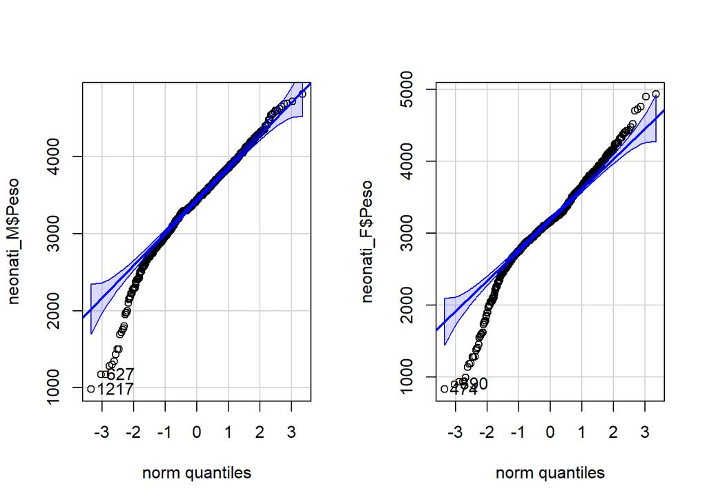

```
[1] 474 890
```

```r
car::qqPlot(neonati_F$Peso)
```

Per entrambi i gruppi il p-value restituito è estremamente basso, molto minore rispetto al valore soglia di 0.05, quindi rifiutiamo l’ipotesi che la variabile *Peso* segua una distribuzione normale.

A livello grafico, inoltre, vediamo che i valori più bassi della variabile *Peso*, per entrambi i gruppi, sono al di fuori dell’intervallo di confidenza, confermando la non-normalità ottenuta tramite il test Shapiro-Wilk (addirittura per le neonate femmine anche i valori più alti della variabile *Peso* escono dalle bande di confidenza).

Per completezza, eseguiamo anche il test sull’omogeneità delle varianze tramite il Levene’s test (preferibile all’F-test e al Bartlett’s test, in quanto quest’ultimi richiedono che la variabile segua una distribuzione Normale):

```r
car::leveneTest(Peso ~ Sesso, data = neonati)
```

```
Levene's Test for Homogeneity of Variance (center = median)
        Df F value Pr(>F)
group    1  0.7931 0.3732
      2498
```

Dato che l’ipotesi di normalità è stata rifiutata per entrambi i gruppi, procediamo eseguendo un test non parametrico. In particolare, essendo un test a due campioni, utilizzeremo il test di Mann-Whitney (dove l’ipotesi nulla è che la differenza tra i valori dei due gruppi non sia statisticamente significativa):

```r
wilcox.test(Peso~Sesso, data = neonati)
```

```
    Wilcoxon rank sum test with continuity correction

data:  Peso by Sesso
W = 538641, p-value < 2.2e-16
alternative hypothesis: true location shift is not equal to 0
```

Passiamo ora alla variabile *Lunghezza*:

```r
shapiro.test(neonati_M$Lunghezza)
```

```
    Shapiro-Wilk normality test

data:  neonati_M$Lunghezza
W = 0.92028, p-value < 2.2e-16
```

```r
shapiro.test(neonati_F$Lunghezza)
```

```
    Shapiro-Wilk normality test

data:  neonati_F$Lunghezza
W = 0.89953, p-value < 2.2e-16
```

```r
par(mfrow=c(1,2))
car::qqPlot(neonati_M$Lunghezza)
```

```
[1] 1217  148
```

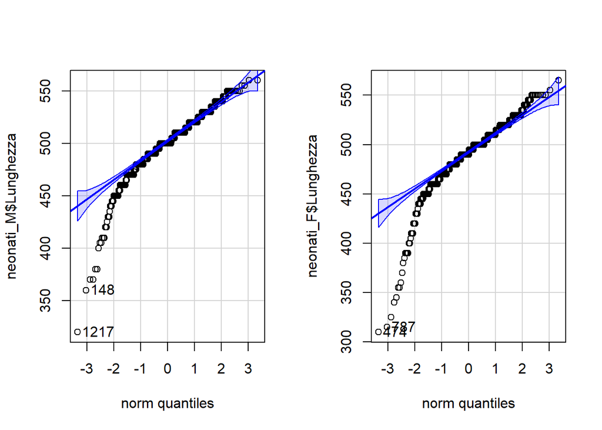

```
[1] 474 787
```

```r
car::qqPlot(neonati_F$Lunghezza)
```

Anche in questo caso il p-value è estremamente basso in entrambi i gruppi, quindi l’assunzione di normalità non è rispettata.

Inoltre anche l’ipotesi di omogeneità delle varianze risulta non soddisfatta:

```r
car::leveneTest(Lunghezza ~ Sesso, data = neonati)
```

```
Levene's Test for Homogeneity of Variance (center = median)
        Df F value   Pr(>F)
group    1  10.496 0.001212 **
      2498
---
Signif. codes:  0 '***' 0.001 '**' 0.01 '*' 0.05 '.' 0.1 ' ' 1
```

Il p-value è infatti pari a 0.001, quindi rifiutiamo l’ipotesi nulla del test di omogeneità delle varianze dei gruppi.

Procediamo eseguendo sia il test di Welch sia quello di Mann-Whitney. In ogni caso, essendo entrambe le assunzioni violate, i risultati dei due test andranno valutati con cautela:

```r
wilcox.test(Lunghezza~Sesso, data = neonati)
```

```
    Wilcoxon rank sum test with continuity correction

data:  Lunghezza by Sesso
W = 594455, p-value < 2.2e-16
alternative hypothesis: true location shift is not equal to 0
```

```r
t.test(neonati_M$Lunghezza, neonati_F$Lunghezza, alternative = "two.sided")
```

```
    Welch Two Sample t-test

data:  neonati_M$Lunghezza and neonati_F$Lunghezza
t = 9.582, df = 2459.3, p-value < 2.2e-16
alternative hypothesis: true difference in means is not equal to 0
95 percent confidence interval:
  7.876273 11.929470
sample estimates:
mean of x mean of y
 499.6672  489.7643
```

Entrambi i test restituiscono un p-value molto piccolo, quindi si rifiuta l’ipotesi nulla di differenza non significativa nelle medie dei due gruppi.

Infine, aiutandoci anche tramite il box-plot:

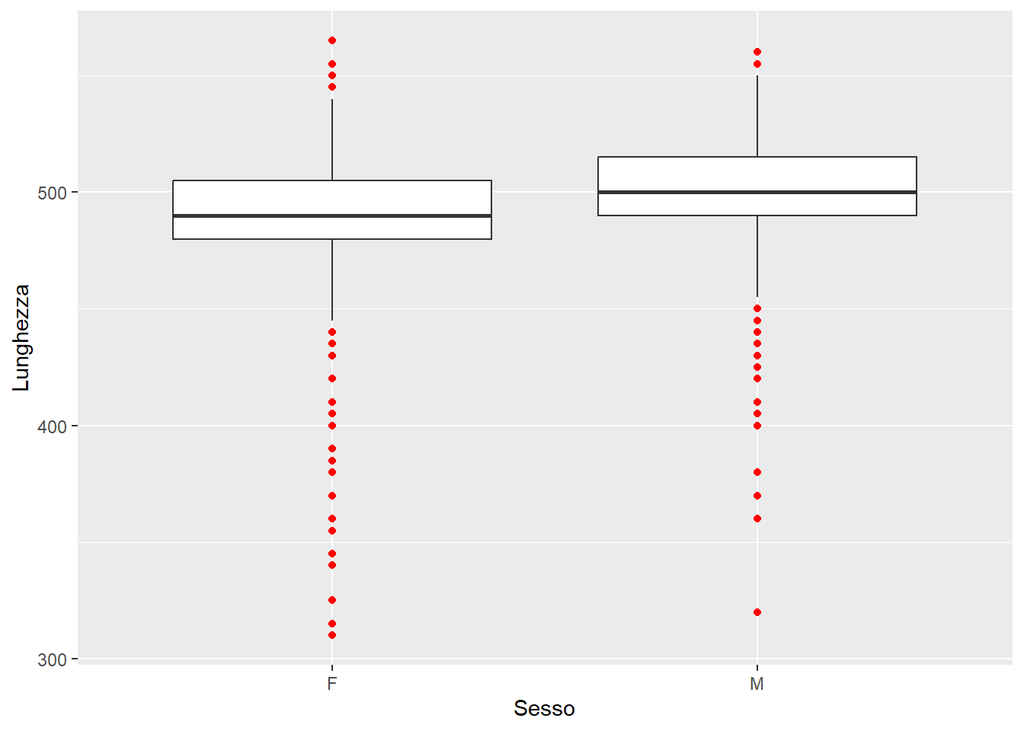

```r
ggplot(neonati)+
  geom_boxplot(aes(x = Sesso,
                   y = Lunghezza
  ),
  outlier.color = "red")+
  theme(legend.position="bottom")
```

Confermiamo che anche per la variabile *Lunghezza* risulta esserci una differenza significativa a seconda che il neonato sia maschio o femmina.

#### 6. Si vocifera che in alcuni ospedali si facciano più parti cesarei, sai verificare questa ipotesi?

Si deve verificare se il numero medio dei parti cesarei nei tre diversi ospedali differescano tra loro in modo significativo.

Si tratta di un test tra medie di tre diversi campioni. Quindi, piuttosto che fare dei test due a due tramite il test t di Student, optiamo per il metodo ANOVA (Analisi della Varianza).

Per utilizzare tale metodo deve essere precedentemente verificato che i dati dei vari gruppi soddisfino:

1. L’ipotesi di normalità
2. L’ipotesi di omogeneità

Partiamo l’analisi codificando la variabile *Tipo.parto* in 1/0 a seconda che il parto sia stato di tipo cesareo o naturale:

```r
neonati$Tipo.parto_dic <- ifelse(neonati$Tipo.parto == "Ces", 1, 0)
```

Per quanto riguarda l’ipotesi di normalità, in questo caso la variabile *Tipo.parto* è una variabile dicotomica, quindi per definizione seguirà una distribuzione Binomiale.

Per quanto riguarda la varianza dei gruppi, essendo la variabile dicotomica, questa sarà sicuramente omogenea.

Nonostante non sia rispettata l’ipotesi di normalità, procediamo comunque con un’analisi ANOVA:

```r
res.aov = aov(neonati$Tipo.parto_dic ~ Ospedale)
summary.lm(res.aov)
```

```
Call:
aov(formula = neonati$Tipo.parto_dic ~ Ospedale)

Residuals:
    Min      1Q  Median      3Q     Max
-0.2992 -0.2966 -0.2778  0.7008  0.7222

Coefficients:
              Estimate Std. Error t value Pr(>|t|)
(Intercept)   0.296569   0.015910  18.640   <2e-16 ***
Ospedaleosp2  0.002607   0.022281   0.117    0.907
Ospedaleosp3 -0.018724   0.022372  -0.837    0.403
---
Signif. codes:  0 '***' 0.001 '**' 0.01 '*' 0.05 '.' 0.1 ' ' 1

Residual standard error: 0.4545 on 2497 degrees of freedom
Multiple R-squared:  0.0004389, Adjusted R-squared:  -0.0003617
F-statistic: 0.5482 on 2 and 2497 DF,  p-value: 0.5781
```

I p-value sono tutti maggiori rispetto al livello di significatività dello 0.05, quindi possiamo concludere che non ci sono differenze significative nei tre ospedali in termini di parti cesarei/naturali.

```r
TukeyHSD(res.aov, conf.level = 0.95)
```

```
  Tukey multiple comparisons of means
    95% family-wise confidence level

Fit: aov(formula = neonati$Tipo.parto_dic ~ Ospedale)

$Ospedale
                  diff         lwr        upr     p adj
osp2-osp1  0.002606873 -0.04964391 0.05485766 0.9924814
osp3-osp1 -0.018724316 -0.07118934 0.03374071 0.6800641
osp3-osp2 -0.021331189 -0.07327797 0.03061559 0.6003928
```

Anche in questo caso i p-value (aggiustati in modo tale che il livello di significatività del test rimanga dello 0.05) sono molto elevati e quindi confermano la non significatività della differenza tra il numero di parti cesarei tra i tre ospedali.

### Analisi multidimensionale:

#### 1. Ricordati qual è l’obiettivo dello studio e indaga le relazioni a due a due, soprattutto con la variabile risposta

La nostra variabile di risposta, Y, sarà il peso del neonato. Le altre variabili rappresentano le nostre variabili esplicative o indipendenti, X.

Per prima cosa, usiamo la funzione `ggcorr()`, che ci permette di valutare il legame a due a due per le variabili continue:

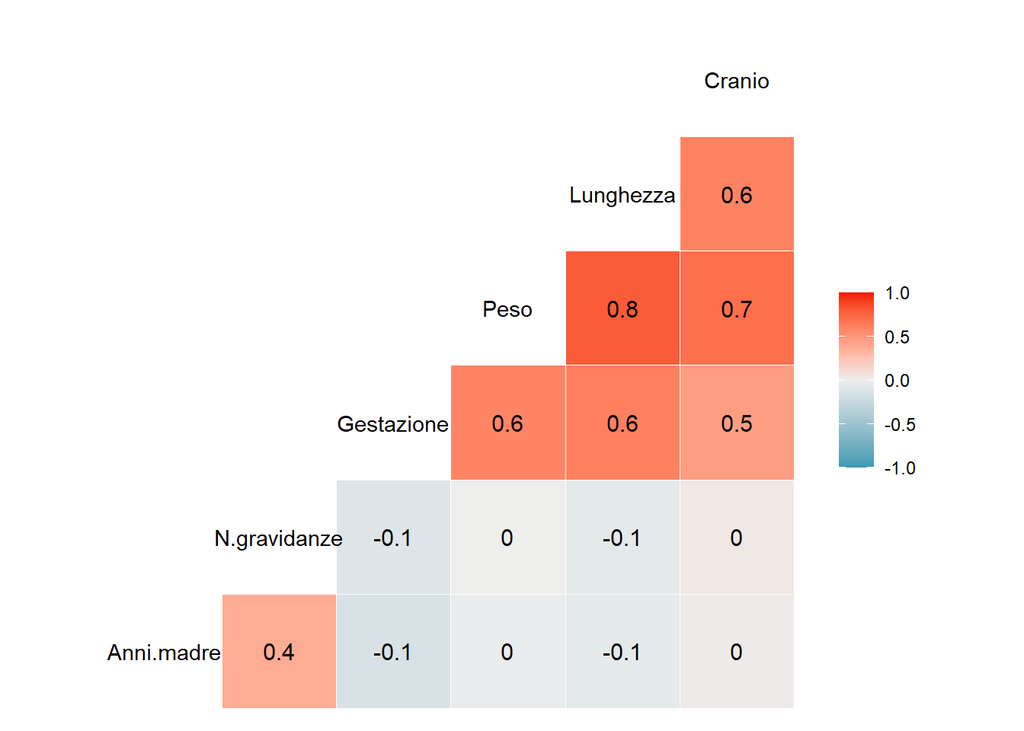

```r
GGally::ggcorr(data = neonati[c(1, 2, 4, 5, 6, 7)], label = TRUE)
```

In particolare, risultano esserci delle forti correlazioni positive tra le variabili *Gestazione*, *Peso*, *Lunghezza* e *Cranio*. Inoltre, c’è anche una correlazione positiva di media intensità tra *Anni.Madre* e *N.gravidanze*. Entrambe le correlazioni sono coerenti con quanto ci aspettavamo.

Aggiungiamo altre informazioni andando a utilizzare la funzione `ggpairs()`:

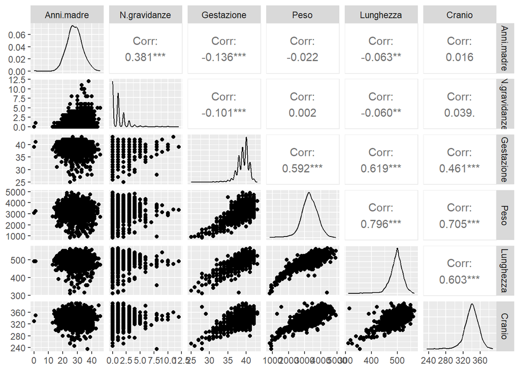

```r
GGally::ggpairs(data = neonati[c(1, 2, 4, 5, 6, 7)])
```

Da cui abbiamo una conferma visiva, grazie agli scatterplot, delle correlazioni positive sopracitate.

Per valutare le relazione tra la variabile *Peso* e le variabili qualitative, invece, possiamo utilizzare il test Chi-Quadro χ<sup>2</sup> di Pearson:

```r
chisq.test(table(Sesso, Peso))
```

```
    Pearson's Chi-squared test

data:  table(Sesso, Peso)
X-squared = 530.52, df = 286, p-value < 2.2e-16
```

```r
chisq.test(table(Fumatrici, Peso))
```

```
    Pearson's Chi-squared test

data:  table(Fumatrici, Peso)
X-squared = 317.11, df = 286, p-value = 0.09958
```

```r
chisq.test(table(Tipo.parto, Peso))
```

```
    Pearson's Chi-squared test

data:  table(Tipo.parto, Peso)
X-squared = 284.13, df = 286, p-value = 0.5202
```

```r
chisq.test(table(Ospedale, Peso))
```

```
    Pearson's Chi-squared test

data:  table(Ospedale, Peso)
X-squared = 560.22, df = 572, p-value = 0.6297
```

I risultati di questi test hanno restituito un solo p-value < α (con α pari a 0.05). Quindi non rifiutiamo l’ipotesi nulla di non associazione significativa tra le due variabili, tranne che per l’associazione tra le variabili *Sesso* e *Peso*, in cui invece risulta esserci un’associazione statisticamente molto significativa.

Da notare, però, che, se aumentassimo il valore di α da 0.05 a 0.10, anche la relazione tra *Peso* e *Fumatrici* diventerebbe statisticamente significativa.

Ci interessa quindi anche valutare un’eventuale associazione tra *Fumatrici* e *Lunghezza*:

```r
chisq.test(table(Fumatrici, Lunghezza))
```

```
    Pearson's Chi-squared test

data:  table(Fumatrici, Lunghezza)
X-squared = 39.995, df = 55, p-value = 0.9359
```

#### 2. Crea un modello di regressione lineare multipla con tutte le variabili e commenta i coefficienti e il risultato ottenuto

```r
mod_completo <- lm(Peso ~ Anni.madre + N.gravidanze + Fumatrici + Gestazione + Lunghezza + Cranio + Tipo.parto + Ospedale + Sesso,
           data = neonati)

summary(mod_completo)
```

```
Call:
lm(formula = Peso ~ Anni.madre + N.gravidanze + Fumatrici + Gestazione +
    Lunghezza + Cranio + Tipo.parto + Ospedale + Sesso, data = neonati)

Residuals:
     Min       1Q   Median       3Q      Max
-1124.40  -181.66   -14.42   160.91  2611.89

Coefficients:
                Estimate Std. Error t value Pr(>|t|)
(Intercept)   -6738.4762   141.3087 -47.686  < 2e-16 ***
Anni.madre        0.8921     1.1323   0.788   0.4308
N.gravidanze     11.2665     4.6608   2.417   0.0157 *
Fumatrici1      -30.1631    27.5386  -1.095   0.2735
Gestazione       32.5696     3.8187   8.529  < 2e-16 ***
Lunghezza        10.2945     0.3007  34.236  < 2e-16 ***
Cranio           10.4707     0.4260  24.578  < 2e-16 ***
Tipo.partoNat    29.5254    12.0844   2.443   0.0146 *
Ospedaleosp2    -11.2095    13.4379  -0.834   0.4043
Ospedaleosp3     28.0958    13.4957   2.082   0.0375 *
SessoM           77.5409    11.1776   6.937 5.08e-12 ***
---
Signif. codes:  0 '***' 0.001 '**' 0.01 '*' 0.05 '.' 0.1 ' ' 1

Residual standard error: 273.9 on 2489 degrees of freedom
Multiple R-squared:  0.7289,    Adjusted R-squared:  0.7278
F-statistic: 669.2 on 10 and 2489 DF,  p-value: < 2.2e-16
```

Partiamo dal fondo: i valori del R-squared e dell’ Adjusted R-squadred sono entrambi simili e pari a 0.72. In sostanza, il modello completo è in grado di spiegare il 72% della variabilità del modello, mentre rimane una parte di variabilità residua pari al 28%. In linea generale, comunque, la varianza spiegata rappresenta una buona percentuale del totale.

Andiamo quindi ad analizzare i singoli coefficienti:

In linea generale, questo modello può essere probabilmente migliorato tramite una riduzione del numero di regressori.

Non risultano significativi nemmeno le variabili *Anni.madre* e *Fumatrici*. Per quest’ultima variabile, però, come visto in precedenza, sembra esserci qualche tipo di relazione con il *Peso*. Inoltre, esistono alcuni studi a riguardo che hanno dimostrato che effettivamente il fumo tende a ridurre il peso del neonato:(https://cordis.europa.eu/article/id/34686-study-shows-mothers-who-smoke-impact-baby-weight-and-size/it#:~:text=Da%20tempo%20i%20ricercatori%20sostengono,meno%20e%20sono%20pi%C3%B9%20piccoli.)

#### 3. Cerca il modello “migliore”, utilizzando tutti i criteri di selezione che conosci e spiegali.

Prima ancora, però, effettuiamo un test di verifica della normalità della variabile *Peso*, in quanto se non segue una distribuzione Normale, probabilmente anche i residui del modello non seguiranno una distribuzione Normale, violando così una delle assunzioni principali del modello lineare:

```r
shapiro.test(Peso)
```

```
    Shapiro-Wilk normality test

data:  Peso
W = 0.97066, p-value < 2.2e-16
```

Il p-value è molto basso, quindi dobbiamo costatare che la variabile non segue una distribuzione Normale.

```r
mod1 <- update(mod_completo, ~ .-Ospedale)
summary(mod1)
```

```
Call:
lm(formula = Peso ~ Anni.madre + N.gravidanze + Fumatrici + Gestazione +
    Lunghezza + Cranio + Tipo.parto + Sesso, data = neonati)

Residuals:
     Min       1Q   Median       3Q      Max
-1141.25  -181.75   -14.87   160.54  2629.75

Coefficients:
                Estimate Std. Error t value Pr(>|t|)
(Intercept)   -6740.6584   141.3921 -47.674   <2e-16 ***
Anni.madre        0.9543     1.1335   0.842   0.3999
N.gravidanze     11.5753     4.6656   2.481   0.0132 *
Fumatrici1      -31.5916    27.5729  -1.146   0.2520
Gestazione       32.8814     3.8227   8.602   <2e-16 ***
Lunghezza        10.2718     0.3010  34.128   <2e-16 ***
Cranio           10.4828     0.4266  24.573   <2e-16 ***
Tipo.partoNat    30.2808    12.0990   2.503   0.0124 *
SessoM           78.0278    11.1921   6.972    4e-12 ***
---
Signif. codes:  0 '***' 0.001 '**' 0.01 '*' 0.05 '.' 0.1 ' ' 1

Residual standard error: 274.3 on 2491 degrees of freedom
Multiple R-squared:  0.7279,    Adjusted R-squared:  0.727
F-statistic:   833 on 8 and 2491 DF,  p-value: < 2.2e-16
```

La rimozione della variabile non ha sostanzialmente avuto effetti nè sulla significatività delle altre variabili indipendenti nè sul valore dell’R-quadro aggiustato.

Procediamo quindi con un’ulteriore rimozione, questa volta è la variabile relativa agli anni della madre:

```r
mod2 <- update(mod1, ~ .-Anni.madre)
summary(mod2)
```

```
Call:
lm(formula = Peso ~ N.gravidanze + Fumatrici + Gestazione + Lunghezza +
    Cranio + Tipo.parto + Sesso, data = neonati)

Residuals:
     Min       1Q   Median       3Q      Max
-1130.04  -181.29   -16.31   160.59  2635.32

Coefficients:
               Estimate Std. Error t value Pr(>|t|)
(Intercept)   -6708.074    135.984 -49.330  < 2e-16 ***
N.gravidanze     13.012      4.342   2.997  0.00276 **
Fumatrici1      -31.759     27.570  -1.152  0.24946
Gestazione       32.541      3.801   8.561  < 2e-16 ***
Lunghezza        10.272      0.301  34.129  < 2e-16 ***
Cranio           10.501      0.426  24.648  < 2e-16 ***
Tipo.partoNat    30.296     12.098   2.504  0.01234 *
SessoM           78.114     11.191   6.980 3.77e-12 ***
---
Signif. codes:  0 '***' 0.001 '**' 0.01 '*' 0.05 '.' 0.1 ' ' 1

Residual standard error: 274.3 on 2492 degrees of freedom
Multiple R-squared:  0.7278,    Adjusted R-squared:  0.7271
F-statistic:   952 on 7 and 2492 DF,  p-value: < 2.2e-16
```

Anche in questo caso coefficienti e R-quadro aggiustato non hanno subìto variazioni significative.

Procediamo quindi con la rimozione anche dell’ultima variabile non significativa, *Fumatrici*:

```r
mod3 <- update(mod2, ~.-Fumatrici)
summary(mod3)
```

```
Call:
lm(formula = Peso ~ N.gravidanze + Gestazione + Lunghezza + Cranio +
    Tipo.parto + Sesso, data = neonati)

Residuals:
     Min       1Q   Median       3Q      Max
-1129.31  -181.70   -16.31   161.07  2638.85

Coefficients:
                Estimate Std. Error t value Pr(>|t|)
(Intercept)   -6707.2971   135.9911 -49.322  < 2e-16 ***
N.gravidanze     12.7558     4.3366   2.941   0.0033 **
Gestazione       32.2713     3.7941   8.506  < 2e-16 ***
Lunghezza        10.2864     0.3007  34.207  < 2e-16 ***
Cranio           10.5057     0.4260  24.659  < 2e-16 ***
Tipo.partoNat    30.0342    12.0969   2.483   0.0131 *
SessoM           77.9285    11.1905   6.964 4.22e-12 ***
---
Signif. codes:  0 '***' 0.001 '**' 0.01 '*' 0.05 '.' 0.1 ' ' 1

Residual standard error: 274.3 on 2493 degrees of freedom
Multiple R-squared:  0.7277,    Adjusted R-squared:  0.727
F-statistic:  1110 on 6 and 2493 DF,  p-value: < 2.2e-16
```

E, ancora una volta, la perdita di informazione del modello legata alla rimozione di un regressore è trascurabile.

Infine vediamo cosa accade nel rimuovere anche la variabile relativa alla modalità con cui è estato effettuato il parto, cesareo o naturale, che avrebbe comunque un p-value significativo per α = 0.05:

```r
mod4 <- update(mod3, ~.-Tipo.parto)
summary(mod4)
```

```
Call:
lm(formula = Peso ~ N.gravidanze + Gestazione + Lunghezza + Cranio +
    Sesso, data = neonati)

Residuals:
     Min       1Q   Median       3Q      Max
-1149.44  -180.81   -15.58   163.64  2639.72

Coefficients:
               Estimate Std. Error t value Pr(>|t|)
(Intercept)  -6681.1445   135.7229 -49.226  < 2e-16 ***
N.gravidanze    12.4750     4.3396   2.875  0.00408 **
Gestazione      32.3321     3.7980   8.513  < 2e-16 ***
Lunghezza       10.2486     0.3006  34.090  < 2e-16 ***
Cranio          10.5402     0.4262  24.728  < 2e-16 ***
SessoM          77.9927    11.2021   6.962 4.26e-12 ***
---
Signif. codes:  0 '***' 0.001 '**' 0.01 '*' 0.05 '.' 0.1 ' ' 1

Residual standard error: 274.6 on 2494 degrees of freedom
Multiple R-squared:  0.727, Adjusted R-squared:  0.7265
F-statistic:  1328 on 5 and 2494 DF,  p-value: < 2.2e-16
```

Il modello contenente le variabili indipendenti *N.gravidanze*, *Gestazione*, *Lunghezza*, *Cranio* e *Sesso* sembra quindi essere il miglior modello, anche in termini di trade-off tra varianza spiegata e numero di regressori.

Per verificare ciò, sfruttiamo i criteri BIC e AIC per la scelta del modello:

- criterio BIC:

```r
BIC(mod_completo, mod1, mod2, mod3, mod4)
```

```
             df      BIC
mod_completo 12 35241.84
mod1         10 35235.35
mod2          9 35228.24
mod3          8 35221.75
mod4          7 35220.10
```

Il modello 4, secondo tale criterio, è il migliore.

- criterio AIC:

```r
AIC(mod_completo, mod1, mod2, mod3, mod4)
```

```
             df      AIC
mod_completo 12 35171.95
mod1         10 35177.11
mod2          9 35175.83
mod3          8 35175.16
mod4          7 35179.33
```

Secondo L’AIC il modello 3 risulta essere preferibile rispetto al modello 4.

Andiamo quindi ad effettuare un test dell’Analisi della varianza (ANOVA) tra i due modelli, il test mette a confronto le varianze spiegate dei modelli indicandoci se la differenza è statisticamente significativa:

```r
anova(mod4, mod3)
```

```
Analysis of Variance Table

Model 1: Peso ~ N.gravidanze + Gestazione + Lunghezza + Cranio + Sesso
Model 2: Peso ~ N.gravidanze + Gestazione + Lunghezza + Cranio + Tipo.parto +
    Sesso
  Res.Df       RSS Df Sum of Sq      F Pr(>F)
1   2494 188065546
2   2493 187601677  1    463870 6.1643 0.0131 *
---
Signif. codes:  0 '***' 0.001 '**' 0.01 '*' 0.05 '.' 0.1 ' ' 1
```

Il p-value è minore del valore soglia 0.05, quindi rifiutiamo l’ipotesi nulla del test: la riduzione di varianza passando dal modello 4 al modello 3 è statisticamente significativa.

Alla fine optiamo comunque per il modello 4 in quanto, a livello statistico, rimane il fatto che l’R quadro aggiustato non è variato molto, inoltre, a livello logico, non sussiste una vera e propria dipendenza tra la variabile *Peso* e la variabile *Tipo.parto*: la relazione tra le due variabili deve essere ricondotta al fatto che il parto cesareo è tendenzialmente programmato intorno alla 38-39esima settimana di gravidanza, mentre il parto naturale può, ovviamente, avvenire anche più tardi, quindi il neonato ha più tempo per aumentare di peso.  
Infine, seguendo il criterio del “Rasoio di Occam”, quando siamo indecisi dobbiamo preferire modelli più semplici.

Avremmo potuto anche eseguire questi test tramite una funzione apposita, `stepAIC()`, che ci permette di scegliere sia la modalità con cui la funzione arriva a trovare il modello migliore (cioè se partire dal modello più semplice o dal modello con tutti i regressori e andare rispettivamente ad aggiungere/togliere regressori, oppure come nel nostro caso levando e aggiungendo regressori a seconda delle circostanze) sia il criterio di scelta (AIC/BIC, nel nostro caso il BIC):

```r
n <- nrow(neonati)
stepwise.mod <- MASS::stepAIC(mod_completo,
                              direction = "both",
                              k =log(n)) #k = 2 per il criterio AIC
```

```
Start:  AIC=28139.32
Peso ~ Anni.madre + N.gravidanze + Fumatrici + Gestazione + Lunghezza +
    Cranio + Tipo.parto + Ospedale + Sesso

               Df Sum of Sq       RSS   AIC
- Anni.madre    1     46578 186809099 28132
- Fumatrici     1     90019 186852540 28133
- Ospedale      2    685979 187448501 28133
- N.gravidanze  1    438452 187200974 28137
- Tipo.parto    1    447929 187210450 28138
<none>                      186762521 28139
- Sesso         1   3611021 190373542 28179
- Gestazione    1   5458403 192220925 28204
- Cranio        1  45326172 232088693 28675
- Lunghezza     1  87951062 274713583 29096

Step:  AIC=28132.12
Peso ~ N.gravidanze + Fumatrici + Gestazione + Lunghezza + Cranio +
    Tipo.parto + Ospedale + Sesso

               Df Sum of Sq       RSS   AIC
- Fumatrici     1     90897 186899996 28126
- Ospedale      2    692738 187501837 28126
- Tipo.parto    1    448222 187257321 28130
<none>                      186809099 28132
- N.gravidanze  1    633756 187442855 28133
+ Anni.madre    1     46578 186762521 28139
- Sesso         1   3618736 190427835 28172
- Gestazione    1   5412879 192221978 28196
- Cranio        1  45588236 232397335 28670
- Lunghezza     1  87950050 274759149 29089

Step:  AIC=28125.51
Peso ~ N.gravidanze + Gestazione + Lunghezza + Cranio + Tipo.parto +
    Ospedale + Sesso

               Df Sum of Sq       RSS   AIC
- Ospedale      2    701680 187601677 28119
- Tipo.parto    1    440684 187340680 28124
<none>                      186899996 28126
```

[output cut: 23 more lines]

```

Step:  AIC=28117.58
Peso ~ N.gravidanze + Gestazione + Lunghezza + Cranio + Sesso

               Df Sum of Sq       RSS   AIC
<none>                      188065546 28118
- N.gravidanze  1    623141 188688687 28118
+ Tipo.parto    1    463870 187601677 28119
+ Ospedale      2    724866 187340680 28124
+ Fumatrici     1     91892 187973654 28124
+ Anni.madre    1     54816 188010731 28125
- Sesso         1   3655292 191720838 28158
- Gestazione    1   5464853 193530399 28181
- Cranio        1  46108583 234174130 28658
- Lunghezza     1  87632762 275698308 29066
```

```r
summary(stepwise.mod)
```

```
Call:
lm(formula = Peso ~ N.gravidanze + Gestazione + Lunghezza + Cranio +
    Sesso, data = neonati)

Residuals:
     Min       1Q   Median       3Q      Max
-1149.44  -180.81   -15.58   163.64  2639.72

Coefficients:
               Estimate Std. Error t value Pr(>|t|)
(Intercept)  -6681.1445   135.7229 -49.226  < 2e-16 ***
N.gravidanze    12.4750     4.3396   2.875  0.00408 **
Gestazione      32.3321     3.7980   8.513  < 2e-16 ***
Lunghezza       10.2486     0.3006  34.090  < 2e-16 ***
Cranio          10.5402     0.4262  24.728  < 2e-16 ***
SessoM          77.9927    11.2021   6.962 4.26e-12 ***
---
Signif. codes:  0 '***' 0.001 '**' 0.01 '*' 0.05 '.' 0.1 ' ' 1

Residual standard error: 274.6 on 2494 degrees of freedom
Multiple R-squared:  0.727, Adjusted R-squared:  0.7265
F-statistic:  1328 on 5 and 2494 DF,  p-value: < 2.2e-16
```

Infine, valutiamo anche eventuali problematiche legate alla multicollinearità, cioè quando le variabili indipendenti sono tra loro fortemente correlate (l’incorrelazione delle variabili indipendenti rappresentano una delle assunzioni del modello lineare):

```r
car::vif(mod4)
```

```
N.gravidanze   Gestazione    Lunghezza       Cranio        Sesso
    1.023475     1.669189     2.074689     1.624465     1.040054
```

I valori sono tutti minori di 5, quindi non abbiamo problemi da questo punto di vista.

#### 4. Si potrebbero considerare interazioni o effetti non lineari?

Dalle precedenti analisi degli scatterplot, che riportiamo di nuovo:

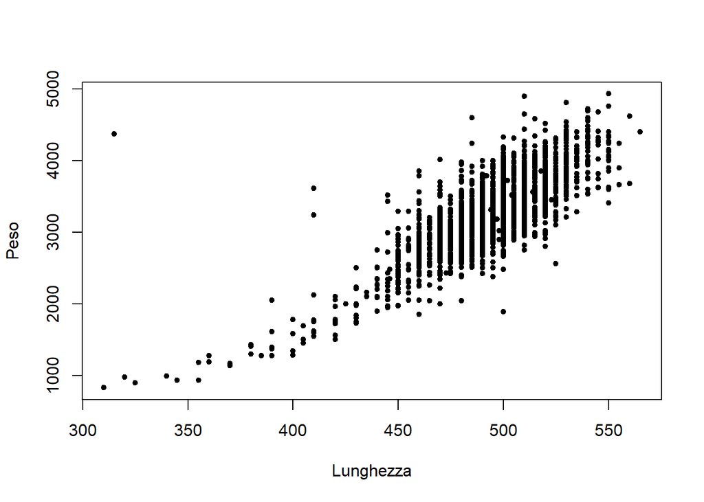

```r
plot(Lunghezza, Peso, pch = 20)
```

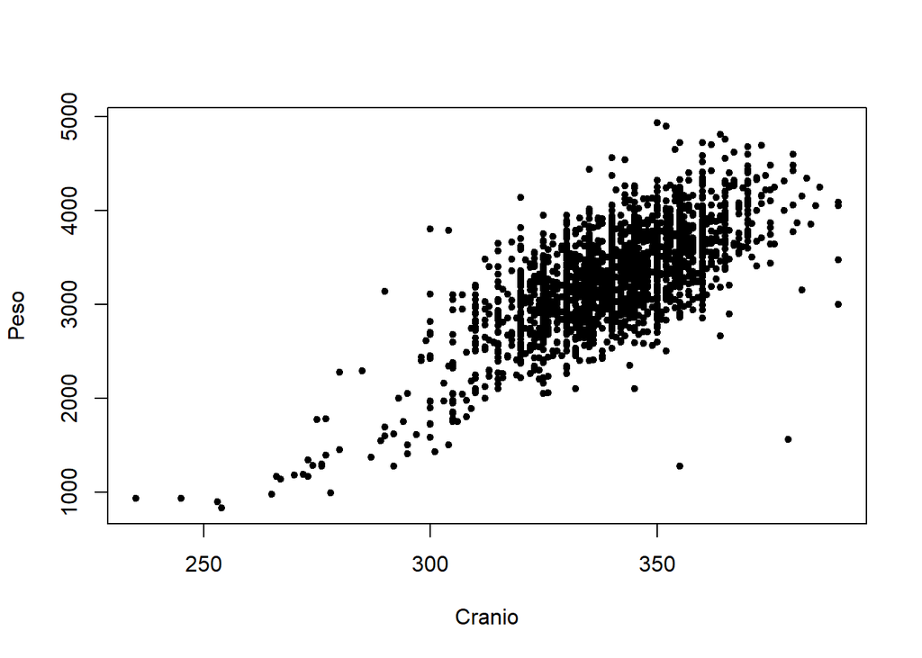

```r
plot(Cranio, Peso, pch = 20)
```

Potrebbe esserci una relazione quadratica della variabile *Lunghezza*. Proviamo quindi ad inserirla nel modello:

```r
mod5 <- update(mod4,~ .+I(Lunghezza^2))
summary(mod5)
```

```
Call:
lm(formula = Peso ~ N.gravidanze + Gestazione + Lunghezza + Cranio +
    Sesso + I(Lunghezza^2), data = neonati)

Residuals:
     Min       1Q   Median       3Q      Max
-1169.72  -181.62   -12.97   163.67  1786.43

Coefficients:
                 Estimate Std. Error t value Pr(>|t|)
(Intercept)    215.090502 723.560129   0.297 0.766287
N.gravidanze    14.098080   4.264177   3.306 0.000959 ***
Gestazione      42.504831   3.873807  10.972  < 2e-16 ***
Lunghezza      -20.272927   3.161377  -6.413  1.7e-10 ***
Cranio          10.650445   0.418670  25.439  < 2e-16 ***
SessoM          70.007371  11.029627   6.347  2.6e-10 ***
I(Lunghezza^2)   0.031664   0.003265   9.697  < 2e-16 ***
---
Signif. codes:  0 '***' 0.001 '**' 0.01 '*' 0.05 '.' 0.1 ' ' 1

Residual standard error: 269.6 on 2493 degrees of freedom
Multiple R-squared:  0.7369,    Adjusted R-squared:  0.7363
F-statistic:  1164 on 6 and 2493 DF,  p-value: < 2.2e-16
```

Il coefficiente della variabile *Lunghezza* al quadrato è statisticamente molto significativo. Inoltre il valore dell’R quadro aggiustato è aumentato.

Rieffettuiamo i test AIC/BIC/ANOVA:

```r
BIC(mod_completo, mod1, mod2, mod3, mod4, mod5)
```

```
             df      BIC
mod_completo 12 35241.84
mod1         10 35235.35
mod2          9 35228.24
mod3          8 35221.75
mod4          7 35220.10
mod5          8 35135.36
```

```r
AIC(mod_completo, mod1, mod2, mod3, mod4, mod5)
```

```
             df      AIC
mod_completo 12 35171.95
mod1         10 35177.11
mod2          9 35175.83
mod3          8 35175.16
mod4          7 35179.33
mod5          8 35088.77
```

```r
anova(mod5, mod4)
```

```
Analysis of Variance Table

Model 1: Peso ~ N.gravidanze + Gestazione + Lunghezza + Cranio + Sesso +
    I(Lunghezza^2)
Model 2: Peso ~ N.gravidanze + Gestazione + Lunghezza + Cranio + Sesso
  Res.Df       RSS Df Sum of Sq      F    Pr(>F)
1   2493 181230058
2   2494 188065546 -1  -6835489 94.029 < 2.2e-16 ***
---
Signif. codes:  0 '***' 0.001 '**' 0.01 '*' 0.05 '.' 0.1 ' ' 1
```

Adesso sia il BIC che l’AIC sono concordi nella scelta del modello migliore, cioè quello con la presenza dell’effetto quadratico della variabile *Lunghezza*. Oltretutto il test ANOVA restituisce un p-value estremamente basso, sintomo che c’è una differenza statisticamente significativa tra le varianze dei due modelli.

Per quanto riguarda le interazioni tra le variabili, dai grafici non ci sono evidenze a riguardo. Tuttavia proviamo ad aggiungere al modello 4 l’interazione tra *Gestazione* e *Cranio* per vedere cosa accade:

```r
mod6 <- update(mod4,~ .+Gestazione*Cranio)
summary(mod6)
```

```
Call:
lm(formula = Peso ~ N.gravidanze + Gestazione + Lunghezza + Cranio +
    Sesso + Gestazione:Cranio, data = neonati)

Residuals:
     Min       1Q   Median       3Q      Max
-1137.16  -180.86   -12.44   167.43  2696.03

Coefficients:
                    Estimate Std. Error t value Pr(>|t|)
(Intercept)       -193.11866 1106.42819  -0.175  0.86145
N.gravidanze        13.14181    4.31191   3.048  0.00233 **
Gestazione        -140.67784   29.52621  -4.765 2.00e-06 ***
Lunghezza           10.47042    0.30096  34.790  < 2e-16 ***
Cranio              -9.83681    3.47497  -2.831  0.00468 **
SessoM              72.05680   11.17200   6.450 1.34e-10 ***
Gestazione:Cranio    0.53339    0.09028   5.908 3.94e-09 ***
---
Signif. codes:  0 '***' 0.001 '**' 0.01 '*' 0.05 '.' 0.1 ' ' 1

Residual standard error: 272.8 on 2493 degrees of freedom
Multiple R-squared:  0.7308,    Adjusted R-squared:  0.7301
F-statistic:  1128 on 6 and 2493 DF,  p-value: < 2.2e-16
```

Il risultato finale è effettivamente un aumento della varianza spiegata dal modello, tuttavia questo aumento è minore rispetto al modello con l’effetto quadratico della variabile *Lunghezza*.

#### 5. Effettua una diagnostica approfondita dei residui del modello e di potenziali valori influenti. Se ne trovi prova a verificare la loro effettiva influenza

L’obiettivo principale dell’analisi residua è valutare la bontà del nostro modello di regressione lineare. Analizzando le caratteristiche dei residui, infatti, possiamo determinare se il modello ha catturato in modo adeguato la relazione tra le variabili dipendenti e indipendenti.

In particolare, l’analisi dei residui si sostanzia nel determinare potenziali problemi legati alla normalità, all’eteroschedasticità e all’autocorrelazione dei residui, oltre che all’identificazione di valori influenti, ovvero valori estremi che possono avere un impatto signifciativo sui risultati del modello di regressione).

Per prima cosa, partiamo con una serie di grafici volti a questo scopo:

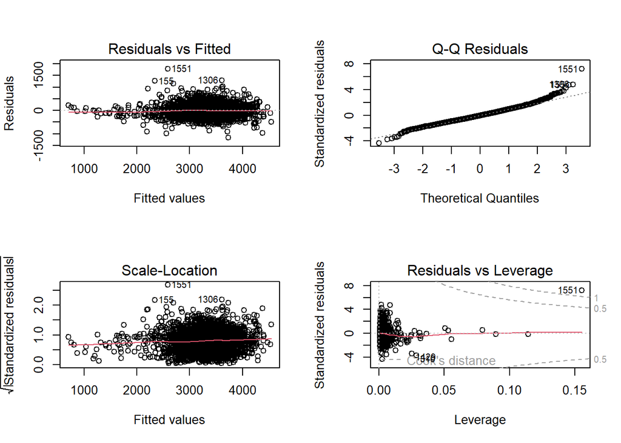

```r
par(mfrow = c(2,2))
plot(mod5)
```

Vediamo i risultati grafici in dettaglio:

- Residuals vs Fitted: i residui sembrano essere sparsi in maniera casuale intorno alla media di (ovvero non sembrerebbe esserci correlazione tra residui)
- Q-Q Residuals: i valori dei residui non seguono la bisettirce (no normalità dei residui)
- Scale-Location: la nuvola dei punti assume una forma quasi ovale, il che fa pensare che possa non essere rispettata l’ipotesi di omoschedasticità dei residui
- Residuals vs Leverage: è presente un valore influente, l’osservazione 1551, che ha una distanza di cook addirittura maggiore di 1

Procediamo quindi nel verificare le sopracitate assunzioni alla base del modello di regressione lineare:

1. normalità dei residui:

   ```r
   shapiro.test(residuals(mod5))
   ```

   ```
       Shapiro-Wilk normality test

   data:  residuals(mod5)
   W = 0.98567, p-value = 3.507e-15
   ```

il p-value riusltante dal test è molto basso: confermiamo quanto visto nel grafico e rifiutiamo l’ipotesi di normalità dei residui. La prima assunzione del modello lineare è quindi non soddisfatta.

2. omoschedasticità dei residui:

   ```r
   lmtest::bptest(mod5)
   ```

   ```
       studentized Breusch-Pagan test

   data:  mod5
   BP = 127.71, df = 6, p-value < 2.2e-16
   ```

anche in questo caso il p-value è molto basso, quindi si rifiuta anche lìipotesi di omoschedasticità dei residui. La seconda assunzione del modello lineare non è stata soddisfataa.

3. incorrelazione dei residui:

   ```r
   lmtest::dwtest(mod5)
   ```

   ```
       Durbin-Watson test

   data:  mod5
   DW = 1.948, p-value = 0.09658
   alternative hypothesis: true autocorrelation is greater than 0
   ```

il p-value è pari a 0.09, superiore rispetto ai valori soglia di 0.05. Non rifiutiamo l’ipotesi di incorrelazione dei residui. La terza assunzione del modello è quindi soddisfatta

4. valori influenti - leverage:

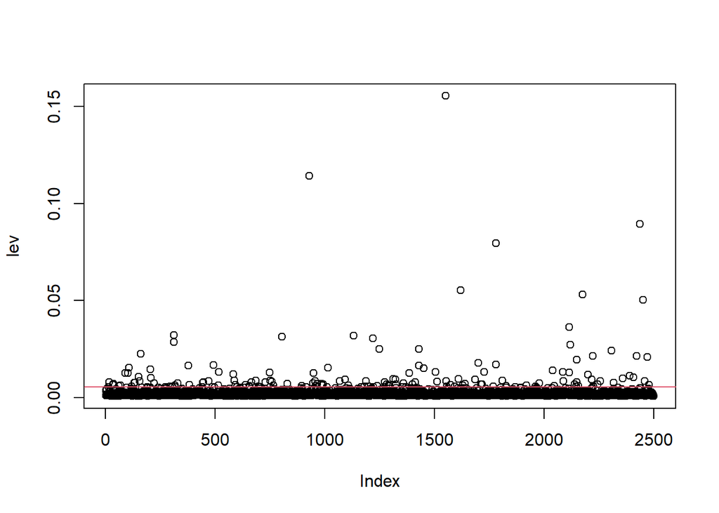

   ```r
   lev <- hatvalues(mod5)
   plot(lev)
   p = sum(lev)
   soglia = 2*p/n
   abline(h=soglia, col=2)
   ```

   ```r
   lev[lev>soglia]
   ```

   ```
            13          15          34          36          61          67
   0.005634869 0.007953628 0.006801125 0.007142279 0.006193064 0.006479391
            89         101         106         119         131         134
   0.012825740 0.012617051 0.015606106 0.005761506 0.007705867 0.007699479
           151         155         161         204         206         220
   0.010910938 0.008665833 0.022740558 0.014722552 0.010199886 0.007554090
           294         304         305         310         312         317
   0.005914093 0.005615047 0.005965394 0.028816859 0.032319968 0.006523544
           328         378         383         442         445         471
   0.007525834 0.016630531 0.006579933 0.007742763 0.008082861 0.008729915
           492         513         516         582         587         592
   0.016833677 0.006288134 0.013171482 0.012190889 0.008822150 0.006622063
           638         656         666         684         697         702
   0.006769838 0.006077138 0.007967275 0.008855606 0.005866150 0.005651289
           706         729         748         750         757         765
   0.005690132 0.008015293 0.013059063 0.008900844 0.008237636 0.006482169
           805         828         895         928         946         947
   0.031313814 0.007206291 0.006150220 0.114130261 0.007489628 0.012745501
           956         958         964         985         988         991
   0.008674487 0.006144891 0.007250098 0.007175695 0.006300736 0.006981729
          1008        1014        1067        1091        1106        1130
   0.005615279 0.015418438 0.008503442 0.009549121 0.006326939 0.031858585
          1181        1188        1200        1219        1238        1248
   0.006006573 0.008658952 0.005738985 0.030710449 0.006148478 0.024997142
          1273        1283        1291        1293        1311        1321
   0.008203801 0.007040095 0.006411852 0.006233646 0.009663319 0.009397899
          1323        1356        1357        1385        1400        1411
   0.007023761 0.005691460 0.007430895 0.012790730 0.007004759 0.008109114
          1428        1429        1450        1505        1513        1551
   0.016546609 0.025033850 0.015104858 0.013344436 0.008332120 0.155288243
          1553        1556        1573        1593        1610        1619
   0.008521454 0.005950369 0.006561552 0.005978839 0.009689449 0.055443052
          1628        1639        1686        1701        1712        1718
   0.006408565 0.007366337 0.009498373 0.017997508 0.007034081 0.007021141
          1727        1767        1780        1781        1809        1827
   0.013410542 0.005922535 0.079399683 0.017029511 0.008759691 0.006167164
          1920        1962        1977        2040        2046        2086
   0.006533051 0.005835829 0.007596511 0.014082178 0.006018228 0.013194120
          2089        2114        2115        2120        2140        2146
   0.008575849 0.036344381 0.012883892 0.027245272 0.007092332 0.005948932
          2148        2149        2157        2175        2200        2216
   0.008017486 0.019606898 0.006133516 0.053138475 0.011847502 0.009363536
          2221        2224        2225        2244        2257        2307
   0.021630424 0.005846820 0.006146225 0.006947953 0.008754217 0.024400052
          2317        2359        2391        2408        2422        2437
   0.007687273 0.010073932 0.011397012 0.010442145 0.021535565 0.089481407
          2452        2458        2471        2478
   0.050473117 0.008596187 0.020970359 0.006810728
   ```

Sono cioè stati identificati ben 142 leverage.